# R Notebook

### Exercise 7.5.2.1

##### Question 1

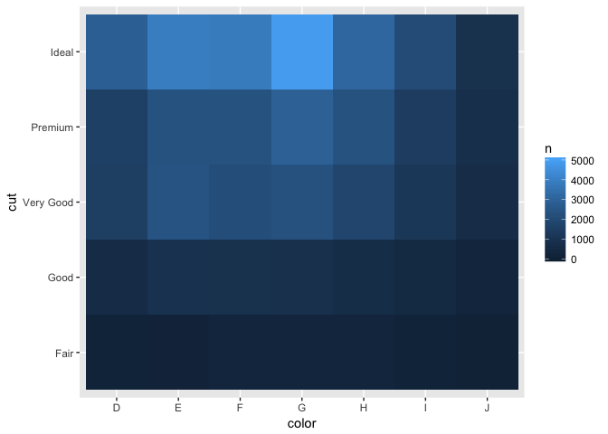

```r
# How could you rescale the count dataset above to more clearly show the distribution of cut within colour, or colour within cut?

diamond_count <- diamonds %>%
  count(color, cut)

diamonds %>%
  count(color, cut) %>%
  ggplot(mapping = aes(x = color, y = cut)) +
    geom_tile(mapping = aes(fill = n)) +
scale_fill_continuous(limits=c(0, 5000))
```

##### Question 2

```r
# Use geom_tile() together with dplyr to explore how average flight delays vary by destination and month of year. What makes the plot difficult to read? How could you improve it?

library(nycflights13)

head(flights)
```

```
## # A tibble: 6 × 19
##    year month   day dep_time sched_dep_time dep_delay arr_time
##   <int> <int> <int>    <int>          <int>     <dbl>    <int>
## 1  2013     1     1      517            515         2      830
## 2  2013     1     1      533            529         4      850
## 3  2013     1     1      542            540         2      923
## 4  2013     1     1      544            545        -1     1004
## 5  2013     1     1      554            600        -6      812
## 6  2013     1     1      554            558        -4      740
## # ... with 12 more variables: sched_arr_time <int>, arr_delay <dbl>,
## #   carrier <chr>, flight <int>, tailnum <chr>, origin <chr>, dest <chr>,
## #   air_time <dbl>, distance <dbl>, hour <dbl>, minute <dbl>,
## #   time_hour <dttm>
```

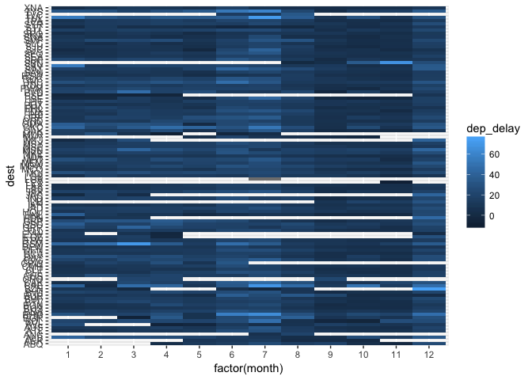

```r
flights %>% group_by(month, dest) %>% summarise(dep_delay = mean(dep_delay, na.rm = TRUE)) %>%  ggplot(aes(x = factor(month), y = dest, fill = dep_delay)) +geom_tile()
```

Too many destinations, could maybe group by state.

##### Question 3

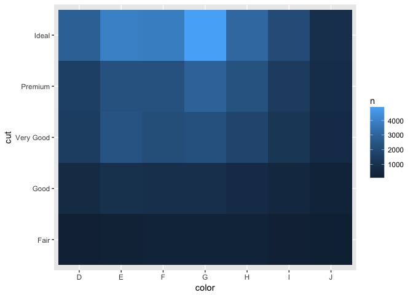

```r
# Why is it slightly better to use aes(x = color, y = cut) rather than aes(x = cut, y = color) in the example above?

diamonds %>%
  count(color, cut) %>%
  ggplot(mapping = aes(x = color, y = cut)) +
    geom_tile(mapping = aes(fill = n))
```

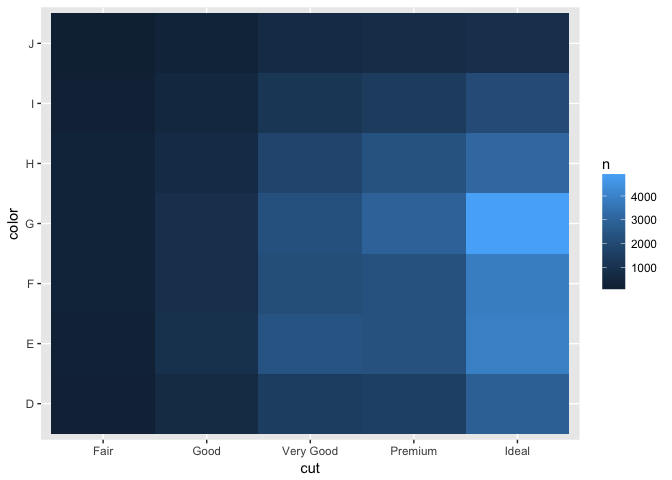

```r
diamonds %>%
  count(color, cut) %>%
  ggplot(mapping = aes(x = cut, y = color)) +
    geom_tile(mapping = aes(fill = n))
```

Astetically it is nicer too look at when there are more columns than rows.

### Exercise 7.5.3.1

##### Question 1

```r
library(hexbin)

#Instead of summarising the conditional distribution with a boxplot, you could use a frequency polygon. What do you need to consider when using cut_width() vs cut_number()? How does that impact a visualisation of the 2d distribution of carat and price?
```

cutwidth is dividing X into bins of a chosen width. Cut_number changes the width of the box to have the same number of datat points in each box. You would need to consider the distribution of your data points when deciding whether or not to use the cut_number, or cut_width. The cut number gives a better idea, visually, of the distribution of your points.

##### Question 2

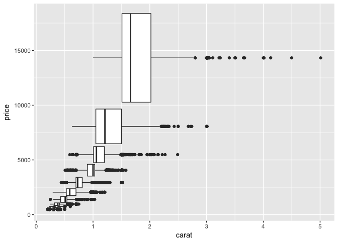

```r
# Visualise the distribution of carat, partitioned by price.

ggplot(diamonds, aes(x = price, y = carat)) +
  geom_boxplot(aes(group=cut_number(price,10))) + coord_flip()
```